# Домашнее задание №2. Линейная регрессия. Расширение признакового пространства. Метрики качества. Валидация.

## Ф.И.О: Бедрин Павел Александрович

### Описание.

Домашнее задание состоит из 2-х частей:

- теоретическая часть
- практическая часть
  - реализация модуля линейной регрессии
  - эксперименты

На проверку требуется отправить zip архив, который будет содержать следующие файлы:

- модуль `modules` с реализованными классами
- заполненный блокнот (теоретическая часть + эксперименты) в формате .ipybn
- заполненный блокнот в формате .html (File -> Save and Export Notebook As -> HTML -> ...)

## Теоретическая часть. (4 points)

**№1.** (1 point) Найдите субдифференциалы для следующих функций:

- $f(x) = \max(0, 1 − ax), \ \ a \ — \ const$, во всех точках
- $f(x) = \sin x, \ x \in [0; \frac{3}{2} \pi]$

**Решение.**

1. $f(x) = \max(0, 1 − ax), \ \ a \ — \ const$, во всех точках

Случай 1. $a < 0$

- Если $x < \frac{1}{a}$: $f(x) = 0$, $f'(x) = 0$, $\partial f(x)=\{0\}$
- Если $x > \frac{1}{a}$: $f(x) = 1 - ax$, $f'(x) = -a$, $\partial f(x)=\{-a\}$
- Если $x = \frac{1}{a}$: $\partial f(x)=[0, -a]$

Случай 2. $a > 0$

- Если $x < \frac{1}{a}$: $f(x) = 1 - ax$, $f'(x) = -a$, $\partial f(x)=\{-a\}$
- Если $x > \frac{1}{a}$: $f(x) = 0$, $f'(x) = 0$, $\partial f(x)=\{0\}$
- Если $x = \frac{1}{a}$: $\partial f(x)=[-a, 0]$

Случай 3. $a = 0$

- $f(x) = 1$, $f'(x) = 0$, $\partial f(x)=\{0\}$
2. $f(x) = \sin x, \ x \in [0; \frac{3}{2} \pi]$
- Если $x = 0$: $\partial f(x)=(-\infty, cosx_0]$, где $x_0$ - абсцисса точки касания касательной $y=xcosx_0$ к графику $f(x)$
- Если $x \in (0, x_0)$: $\partial f(x)=\emptyset$
- Если $x \in [x_0, \frac{3}{2} \pi)$: $\partial f(x)=cosx$
- Если $x = \frac{3}{2} \pi$: $\partial f(x)=[0, +\infty)$

Для лучшего понимания темы был полезен этот [материал](https://fmin.xyz/docs/theory/Subgradient.html).

**№2.** (1 point) Подробнее ознакомьтесь с материалом по ROC-AUC по [ссылке](https://alexanderdyakonov.wordpress.com/2017/07/28/auc-roc-%D0%BF%D0%BB%D0%BE%D1%89%D0%B0%D0%B4%D1%8C-%D0%BF%D0%BE%D0%B4-%D0%BA%D1%80%D0%B8%D0%B2%D0%BE%D0%B9-%D0%BE%D1%88%D0%B8%D0%B1%D0%BE%D0%BA/) и следующую решите задачу:

- Пусть на ответах алгоритма $m$ (принимающих значения от $0$ до $1$) задано распределение объектов класса $1$ (доля объектов класса $1$ в зависимости от ответа алгоритма) следующим образом:
  - $\mathbb{P} (m \in [a, b] \ | \ y = 1) = \int_a^b p(z)dz$
- Распределение объектов класса 0 задаётся так:
  - $\mathbb{P} (m \in [a, b] \ | \ y = 0) = \int_a^b (2 − p(z))dz$

где $p(z) = −1.5z^2 + 3z$

Найдите вероятностные оценки на величины TPR, FPR и ROC-AUC.

**Решение.**

По задаче в материалах А. Дьяконова.

$x$ - порог бинаризации

$TPR(x) = \int_{x}^{1} (-\frac{3}{2}z^2 + 3z) \, dz = [ -\frac{1}{2}z^3 + \frac{3}{2}z^2 ]_{x}^{1} = ( -\frac{1}{2} + \frac{3}{2} ) - ( -\frac{1}{2}x^3 + \frac{3}{2}x^2 ) = 1 + \frac{1}{2}x^3 - \frac{3}{2}x^2.$

$FPR(x) = \int_{x}^{1} (2 + \frac{3}{2}z^2 - 3z) \, dz = [ 2z + \frac{1}{2}z^3 - \frac{3}{2}z^2 ]_{x}^{1} = ( 2 + \frac{1}{2} - \frac{3}{2} ) - ( 2x + \frac{1}{2}x^3 - \frac{3}{2}x^2 ) = 1 - 2x - \frac{1}{2}x^3 + \frac{3}{2}x^2.$

$ROC-AUC = \int_{1}^{0} TPR(x) FPR'(x) \, \partial(x) = \int_{1}^{0} (1 + \frac{1}{2}x^3 - \frac{3}{2}x^2) (1 - 2x - \frac{1}{2}x^3 + \frac{3}{2}x^2)' \, dx =$

$ = \int_{1}^{0} (1 + \frac{1}{2}x^3 - \frac{3}{2}x^2) (- 2 - \frac{3}{2}x^2 + 3x) \, dx = 0.75.$

**№3.** (1 point) Пусть, $a = a(x)$ ответ алгоритма. На сколько может уменьшиться ROC-AUC при использовании функции $\min(a, 0.5)$ над оценками алгоритма?

**Решение.** Рассмотрим идеальный классификатор с ROC-AUC = 1, все оценки которого изначально больше или равны 0.5. После использования функции min все предсказания станут равными 0.5. Объекты с равными оценками на графике отражаются так: из (0,0) делается один шаг в точку правее на *a* клеток, выше на *b*, где *a* - число нулей, *b* - число единиц в истинных метках. Получится диагональ, площадь под которой равна 0.5 = ROC-AUC. Таким образом, ROC-AUC уменьшится на 0.5.

**№4.** (1 point) Докажите, что ROC-AUC случайного классификатора равана $0.5$

**Решение.** Рассмотрим случайный классификатор как бернуллиевскую случайную величину: $p$ — вероятность "1", $1-p$ — вероятность "0". Пусть $k$ — доля объектов класса "1" в некотором датасете, $1-k$ — доля объектов класса "0".

$TPR = \frac{TP}{TP + FN} = \frac{pk}{pk + (1-p)k} = p$

$FPR = \frac{FP}{FP + TN} = \frac{p(1-k)}{p(1-k) + (1-p)(1-k)} = p$

$ROC-AUC = \int_{0}^{1} TPR \, \partial FPR = \int_{0}^{1} p\, \partial p = \frac{1}{2}\rho^2\bigg|_0^1 = 0.5$

## Практическая часть. (16 points)

Данная часть задания направлена на ознакомление с линейными моделями и градиентными методами обучения. В задании необходимо:

1. Написать на языке Python собственную реализацию модели линейной регрессии с произвольной функцией потерь и реализацию функции и градиента функции потерь для линейной регрессии. Реализации можно частично проверить через юнит-тесты (запускаются командой `pytest tests.py`).
2. Провести описанные ниже эксперименты с модельными данными и приложенным датасетом.
3. Написать отчёт о проделанной работе (в формате jupyter notebook).

### Реализация алгоритмов. (3 points)

Везде выборкой объектов будем понимать `numpy.ndarray` размера $N \times D$ или разреженную матрицу `scipy.sparse.csr_matrix` того же размера, под ответами для объектов выборки будем понимать `numpy.ndarray` размера $N$ , где $N$ — количество объектов в выборке, $D$ — размер признакового пространства. Подрузамевается, что первый столбец выборки объектов соответствует признаку для смещения и равен единице.

- **`losses.py`** (1 point)
  - класс в этом модуле задаёт конкретную функцию потерь, которую можно использовать для обучения линейной модели. Обратите внимание на то, что подсчёт всех функций может быть полностью векторизован (т.е. их можно реализовать без циклов). Предложенная в задании функция потерь должна поддерживать использование $l2$-регуляризации. Обратите внимание, что признак для смещения **не** должен учитываться в регуляризаторе.
  - Класс должен поддерживать как плотные матрицы (`numpy.ndarray`), так и разреженные матрицы (`scipy.sparse.csr_matrix`). Класс `LinearLoss` наследуется от абстрактного класса BaseLoss и реализует два метода: `func` и `grad`.
    - `func(self, X, y, w)` — вычисление значения функции потерь на матрице признаков $X$, векторе ответов $y$ с вектором весов $w$.
    - `grad(self, X, y, w)` — вычисление значения градиента функции потерь на матрице признаков $X$, векторе ответов $y$ с вектором весов $w$.
  - У обоих методов одинаковые аргменты:
    - $X$ - выборка объектов
    - $y$ - вектор ответов
    - $w$ - вектор коэффициентов модели `numpy.ndarray`.

В данном задании предлагается реализовать следующую функцию потерь:

$$L(X,y,w, \lambda) = \dfrac{1}{N} \| Xw - y \|_2^2 + \lambda \|w\|_2^2$$

- **`linear_model.py`** (2 points)
  - модуль с реализацией линейной модели, поддерживающей обучение через полный и стохастический градиентные спуски. Линейная модель должна задаваться в классе LinearModel. Параметр $\eta_k > 0$ — темп обучения (learning rate) для градиентного спуска, где $k$ — номер эпохи, должен параметризовываться формулой: $\eta_k = \dfrac{\alpha}{k^{\beta}}, \ где \ \ \alpha, \beta \ — \ \ заданные \ константы, \ \ k \ — \ \ номер \ итерации$
  - Описание методов класса:
    - `__init__` — конструктор (инициализатор) класса с параметрами:
      - `loss_function` — функция потерь, заданная классом, наследованным от `BaseLoss`
      - `batch_size` — размер подвыборки, по которой считается градиент, если `None`, то необходимо использовать полный градиент
      - `step_alpha` — параметр выбора шага градиентного спуска
      - `step_beta` — параметр выбора шага градиентного спуска
      - `tolerance` — точность, по достижении которой, необходимо прекратить оптимизацию
      - `max_iter` — максимальное число итераций
    - `fit(self, X, y, w_0=None, trace=False)` — обучение линейной модели:
      - `X` - выборка объектов
      - `y` - вектор ответов
      - `w_0` - начальное приближение вектора весов, если `None`, то необходимо инициализировать внутри метода
      - `trace` - индикатор, нужно ли возвращать информацию об обучении
        - Если `trace is True`, то метод должен вернуть словарь `history`, содержащий информацию о поведении метода оптимизации во время обучения. Длина словаря `history` — количество эпох. Элементы словаря в случае полного градиентного спуска:
          - `history[’time’]` — содержит время потраченное на обучение каждой эпохи
          - `history[’func’]` — содержит значения функционала на обучающей выборке на каждой эпохе
          - `history[’func_val’]` — содержит значения функционала на валидационной выборке на каждой эпохе
        - Обратите внимание, что `trace is True` сильно замедляет обучение методов, т.к. требует в конце эпохи подсчитывать значение функции. Не используйте его ни в каких экспериментах, кроме экспериментов, где необходимо исследовать поведение функции в зависимости от гиперпараметров.
        - Нет необходимости проводить честное семплирование для каждого батча в методе стохасического градиентного спуска. Вместо этого предлагается в начале одной эпохи сгенерировать случайную перестановку индексов объектов, а затем последовательно выбирать объекты для нового батча из элементов этой перестановки.
    - `predict(self, X)` — получение предсказаний модели
      - `X` - выборка объектов
      - -> Метод должен вернуть `numpy.ndarray` такого же размера, как и первая размерность матрицы `X`.
    - `get_objective(self, X, y)` — получение предсказаний модели
      - `X` - выборка объектов
      - `y` - вектор ответов
      - -> Функция должна вернуть вещественное число..
    - `get_weights(self)` — получить вектор линейных коэффициентов модели

### Эксперименты. (13 points)

Данные для этого задания находятся в файле `hw2_data.csv`. Данные состоят из двух колонок: `text` и `y`. Текст представляет собой комментарии пользователей. А целевая переменная, колонка `y`, отражает степень токсичности комментария, которую вам необходимо будет предсказать.

**1.** (2 points)

*1.1* Произведите предварительную обработку текста. Приведите все тексты к нижнему регистру. Замените в тексте все символы, не являющиеся буквами и цифрами, на пробелы. Примените алгоритм [лемматизации](https://ru.wikipedia.org/wiki/%D0%9B%D0%B5%D0%BC%D0%BC%D0%B0%D1%82%D0%B8%D0%B7%D0%B0%D1%86%D0%B8%D1%8F) (например, [WordNetLemmatizer](https://www.nltk.org/api/nltk.stem.WordNetLemmatizer.html?highlight=wordnet) из библотеки [nltk](https://www.nltk.org/index.html)) к коллекции. Удалите из текста стоп-слова (например, используя список стоп-слов из nltk).

Замечание. Полезные функции: `str.lower`, `str.split`, `str.isalnum`, `re.sub`, `re.split`.

```python
import nltk
import pandas as pd
from nltk.corpus import stopwords
from nltk.stem import WordNetLemmatizer
from nltk.tokenize import word_tokenize

data = pd.read_csv('hw2_data.csv')
data['text'] = data['text'].str.lower()
data['text'] = data['text'].str.replace(r'[^a-z0-9]', ' ', regex=True)

nltk.download('stopwords')
stop_words = set(stopwords.words('english'))
data['text'] = data['text'].apply(lambda text: ' '.join([word for word in word_tokenize(text) if word not in stop_words]))

nltk.download('wordnet')
lemmatizer = WordNetLemmatizer()
data['text'] = data['text'].apply(lambda text: ' '.join([lemmatizer.lemmatize(word) for word in word_tokenize(text)]))
```

```python
data.head()
```

|  | text | y |
| --- | --- | --- |
| 0 | oh dear johnny boy part one want fucking fight... | 2.076477 |
| 1 | savant13 fat shite | 3.580757 |
| 2 | english want get blocked fu k | 0.805528 |
| 3 | fuck care g e r f l l p l e e j ck | 4.582293 |
| 4 | yo dear sir james paul fruity as nigga get lif... | 2.077456 |

*1.2.* Разделите данные на обучение, валидацию и тест. Для теста выберете $30\%$ **случайных** объектов из датасета. Оставшиеся данные разбейте в соотношении $70/30$ (обучение/валидация). Рекомендуется использовать функцию `sklearn.model_selection.train_test_split` c параметром `random_state=42`.

```python
from sklearn.model_selection import train_test_split

X_train, X_test, y_train, y_test = train_test_split(data['text'], data['y'], test_size=0.3, random_state=42)
X_train, X_val, y_train, y_val = train_test_split(X_train, y_train, test_size=0.3, random_state=42)
y_train = y_train.reset_index(drop=True)  # Для выборки по индексам в обучении SGD
```

*1.3.* Преобразуйте текст в разреженную матрицу `scipy.sparse.csr_matrix`, где значение $x$ в позиции $(i, j)$ сответствует [$tf-idf$](https://ru.wikipedia.org/wiki/TF-IDF) характеристке $j$-го слова в $i$-ом документе. Рекомендуется использовать конструктор [`sklearn.feature_extraction.text.TfidfVectorizer`](https://scikit-learn.org/stable/modules/generated/sklearn.feature_extraction.text.TfidfVectorizer.html). Добавьте в данные единичный столбец на нулевой позиции.

Замечание 1. У `TfidfVectorizer` есть несколько методов для работы, используйте `fit_transform` и `fit` для обучающей выборки, используйте `transform` для тестовой.

Замечание 2. Используйте параметр `min_df`, чтобы уменьшить размерность данных и ускорить проведение экспериментов. Рекомендуется использовать `min_df` не меньше 5.

Замечание 3. Для добавления единичного столбца, можно воспользоваться следующей инструкцией: `from scipy.sparse import hstack, csr_matrix X = csr_matrix(hstack([csr_matrix(np.ones((X.shape[0], 1))), X]))`

```python
import numpy as np
from scipy.sparse import hstack, csr_matrix
from sklearn.feature_extraction.text import TfidfVectorizer

vectorizer = TfidfVectorizer(min_df=5)
X_train = vectorizer.fit_transform(X_train)
X_val = vectorizer.transform(X_val)
X_test = vectorizer.transform(X_test)

X_train = hstack([csr_matrix(np.ones((X_train.shape[0], 1))), X_train])
X_val = hstack([csr_matrix(np.ones((X_val.shape[0], 1))), X_val])
X_test = hstack([csr_matrix(np.ones((X_test.shape[0], 1))), X_test])
```

**2.** (3 points) В спецификации предлагается использовать следующую формулу для выбора темпа обучения $\gamma_k$:

$$\gamma_k = \dfrac{\alpha}{k^{\beta}}, \ где \ \ \alpha, \beta \ — \ заданные \ константы, \ \ k \ — \ номер \ итерации$$

- Исследуйте поведение градиентного спуска для задачи линейной регрессии в зависимости от следующих параметров:
  - параметр темпа обучения `step_alpha`
  - параметр темпа обучения `step_beta`
- Исследование поведения подразумевает анализ следующих зависимостей на обучающей и валидационной выборках:
  - зависимость значения функции потерь от реального времени работы метода
  - зависимость значения функции потерь от эпохи метода
  - значение метрики качества после обучения метода

В качестве метрики качества здесь и далее предлагается использовать **MAE**.

[figure not shown]

```python
import numpy as np
import matplotlib.pyplot as plt
from sklearn.metrics import mean_absolute_error

from modules.linear_model import LinearModel
from modules.losses import LinearLoss


alphas = [0.1, 0.5, 1.0]
betas = [0.01, 0.1, 0.5]

# Обучение на разных гиперпараметрах
metrics = {}
for alpha, beta in [(a, b) for a in alphas for b in betas]:
    loss_function = LinearLoss(l2_coef=0.0)
    model = LinearModel(
        loss_function=loss_function,
        step_alpha=alpha,
        step_beta=beta
    )
    history = model.fit(X_train, y_train, trace=True, X_val=X_val, y_val=y_val)
    history['mae_train'] = mean_absolute_error(y_train, model.predict(X_train))
    history['mae_val'] = mean_absolute_error(y_val, model.predict(X_val))
    metrics[(alpha, beta)] = history

cmap = plt.cm.Set1(np.linspace(0, 1, len(alphas) * len(betas)))
plt.figure(figsize=(10, 15))

# График loss vs время
plt.subplot(3, 1, 1)
for idx, (alpha, beta) in enumerate([(a, b) for a in alphas for b in betas]):
    history = metrics[(alpha, beta)]
    plt.plot(np.cumsum(history['time']),
             history['func'],
             color=cmap[idx],
             linestyle='-',
             label=f'train (α={alpha}, β={beta})')
    plt.plot(np.cumsum(history['time']),
             history['func_val'],
             label=f'val (α={alpha}, β={beta})',
             color=cmap[idx],
             linestyle='--')
plt.xlabel('Время (сек)')
plt.ylabel('Loss')
plt.title('Зависимость loss от времени')
plt.legend(bbox_to_anchor=(1, 1))
plt.grid(True)

# График loss vs эпохи
plt.subplot(3, 1, 2)
for idx, (alpha, beta) in enumerate([(a, b) for a in alphas for b in betas]):
    history = metrics[(alpha, beta)]
    epochs = range(len(history['func']))
    plt.plot(epochs,
             history['func'],
             label=f'train (α={alpha}, β={beta})',
             color=cmap[idx],
             linestyle='-')
    plt.plot(epochs,
             history['func_val'],
             label=f'val (α={alpha}, β={beta})',
             color=cmap[idx],
             linestyle='--')
plt.xlabel('Итерация')
plt.ylabel('Loss')
plt.title('Зависимость loss от эпохи')
plt.legend(bbox_to_anchor=(1, 1))
plt.grid(True)

# График MAE vs параметры
plt.subplot(3, 1, 3)
mae_train = []
mae_val = []
labels = []

for alpha, beta in [(a, b) for a in alphas for b in betas]:
    history = metrics[(alpha, beta)]
    mae_train.append(history['mae_train'])
    mae_val.append(history['mae_val'])
    labels.append(f'α={alpha}, β={beta}')

bar_positions = np.arange(len(alphas) * len(betas))
plt.bar(x=bar_positions - 0.1, height=mae_train, width=0.2, label='Train MAE')
plt.bar(x=bar_positions + 0.1, height=mae_val, width=0.2, label='Val MAE')
plt.ylabel('MAE')
plt.title('Зависимость MAE от параметров α и β')
plt.xticks(bar_positions, labels, rotation=45)
plt.legend()
plt.grid(True)

plt.tight_layout()
plt.show()
```

**Вывод**. Исходя из наблюдаемых зависимостей, среди рассмотренных значений $\alpha$ и $\beta$ лучший лосс и MAE на обеих выборках достигается при наименьшем $\beta$ и наибольшем $\alpha$. Возьмём $\alpha = 1.0$ и $\beta = 0.01$.

**5.** (3 points)

- Исследуйте поведение стохастического градиентного спуска для задачи линейной регрессии в зависимости от следующих параметров:
  - параметр темпа обучения `step_alpha`
  - параметр темпа обучения `step_beta`
  - размер подвыборки `batch_size`

Замечание. Обратите внимание, что в стохастическом случае необходимо строить зависимости метрик качества от эпохи метода. За одну эпоху через оптимизацию модели проходит $N$ объектов, где $N$ — длина обучающей выборки. Если вы реализуете семплирование согласно спецификации задания, то за одну эпоху каждый объект пройдёт через оптимизацию ровно один раз. В полном градиентном спуске одна эпоха метода соответствует одной итерации обучения.

```python
from tqdm.notebook import tqdm
from sklearn.metrics import mean_absolute_error

from modules.linear_model import LinearModel
from modules.losses import LinearLoss


batch_sizes = [16, 32, 64]
alphas = [0.1, 0.5, 1.0]
betas = [0.01, 0.1, 0.5]

metrics = {}
for batch_size in tqdm(batch_sizes, desc='Iterate batch size'):
    metrics[batch_size] = {}
    for alpha, beta in tqdm([(a, b) for a in alphas for b in betas],
                           desc=f'Iterate a, b (batch_size={batch_size})',
                           leave=False):
        loss_function = LinearLoss(l2_coef=0.0)
        model = LinearModel(
            loss_function=loss_function,
            batch_size=batch_size,
            step_alpha=alpha,
            step_beta=beta
        )
        history = model.fit(X_train, y_train, trace=True, X_val=X_val, y_val=y_val)
        history['mae_train'] = mean_absolute_error(y_train, model.predict(X_train))
        history['mae_val'] = mean_absolute_error(y_val, model.predict(X_val))
        metrics[batch_size][(alpha, beta)] = history
```

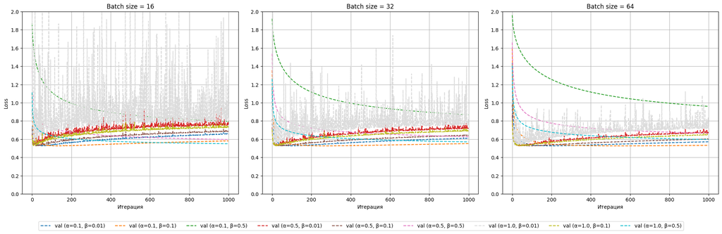

```python
import matplotlib.pyplot as plt


fig, axes = plt.subplots(1, 3, figsize=(20, 6))
cmap = plt.cm.tab10(np.linspace(0, 1, len(alphas) * len(betas)))

for batch_idx, batch_size in enumerate(batch_sizes):
    ax = axes[batch_idx]

    for idx, (alpha, beta) in enumerate([(a, b) for a in alphas for b in betas]):
        result = metrics[batch_size][(alpha, beta)]
        epochs = range(len(result['func']))
        color = cmap[idx]
        if (alpha, beta) == (1.0, 0.01):
            color = 'gainsboro'

        ax.plot(epochs,
                result['func_val'],
                color=color,
                linestyle='--',
                label=f'val (α={alpha}, β={beta})')

    ax.set_xlabel('Итерация')
    ax.set_ylabel('Loss')
    ax.set_title(f'Batch size = {batch_size}')
    ax.set_ylim(0, 2)
    ax.set_yticks(np.arange(0, 2.1, 0.2))
    ax.grid(True)

handles, labels = axes[0].get_legend_handles_labels()
fig.legend(handles, labels, loc='center', bbox_to_anchor=(0.5, -0.05), ncol=len(alphas)*len(betas))
plt.tight_layout()
plt.show()
```

Рассмотрим поведение loss на валидационной выборке:

- При $\alpha = 1.0$ и $\beta = 0.01$ loss очень сильно колеблется, модель не может сойтись к минимуму из-за большого шага.
- При $\beta = 0.5$ loss стабильно снижается, лучше всего на $\alpha = 1.0$. На наборе $\alpha = 0.1$, $\beta = 0.1$, $batch\_size = 64$ тоже наблюдается стабильное снижение.
- На других наборах параметров loss начинает плавно расти, модель переобучается.

```python
results = []
for batch_size in batch_sizes:
    for alpha, beta in [(a, b) for a in alphas for b in betas]:
        history = metrics[batch_size][(alpha, beta)]
        results.append({
            'batch size': batch_size,
            'alpha': alpha,
            'beta': beta,
            'MAE train': history['mae_train'],
            'MAE val': history['mae_val'],
            'Total time': np.sum(history['time'])
        })
df = pd.DataFrame(results)
df = df.round(2)
df_grouped = df.set_index(['batch size', 'alpha', 'beta']).sort_index()
df_grouped
```

| batch size | alpha | beta | MAE train | MAE val | Total time |
| --- | --- | --- | --- | --- | --- |
| 16 | 0.1 | 0.01 | 0.33 | 0.54 | 367.95 |
|  |  | 0.10 | 0.33 | 0.49 | 369.45 |
|  |  | 0.50 | 0.62 | 0.62 | 370.27 |
|  | 0.5 | 0.01 | 0.34 | 0.59 | 369.21 |
|  |  | 0.10 | 0.33 | 0.55 | 369.52 |
|  |  | 0.50 | 0.48 | 0.51 | 368.69 |
|  | 1.0 | 0.01 | 0.76 | 0.88 | 370.18 |
|  |  | 0.10 | 0.33 | 0.58 | 369.98 |
|  |  | 0.50 | 0.43 | 0.48 | 369.31 |
| 32 | 0.1 | 0.01 | 0.33 | 0.51 | 221.33 |
|  |  | 0.10 | 0.34 | 0.47 | 220.60 |
|  |  | 0.50 | 0.65 | 0.65 | 221.24 |
|  | 0.5 | 0.01 | 0.33 | 0.57 | 220.87 |
|  |  | 0.10 | 0.33 | 0.53 | 220.58 |
|  |  | 0.50 | 0.51 | 0.53 | 220.82 |
|  | 1.0 | 0.01 | 0.35 | 0.60 | 220.56 |
|  |  | 0.10 | 0.33 | 0.56 | 220.52 |
|  |  | 0.50 | 0.45 | 0.49 | 220.84 |
| 64 | 0.1 | 0.01 | 0.34 | 0.48 | 141.46 |
|  |  | 0.10 | 0.35 | 0.45 | 141.62 |
|  |  | 0.50 | 0.69 | 0.69 | 141.43 |
|  | 0.5 | 0.01 | 0.33 | 0.55 | 142.03 |
|  |  | 0.10 | 0.33 | 0.50 | 141.40 |
|  |  | 0.50 | 0.54 | 0.55 | 141.50 |
|  | 1.0 | 0.01 | 0.37 | 0.60 | 141.26 |
|  |  | 0.10 | 0.33 | 0.53 | 141.79 |
|  |  | 0.50 | 0.48 | 0.51 | 141.57 |

Видно, что чем больше размер батча, тем меньше времени занимает обучение. С учётом этого факта, MAE на валидации и выводов о loss выше, оптимальным кажется такой набор параметров:

$\alpha = 0.1$, $\beta = 0.1$, $batch\_size = 64$.

**6.** (2 point) Сравните поведение двух методов между собой, сделайте выводы. Сравните оптимальные `step_alpha` и `step_beta` для разных методов.

- В mini-batch SGD зачастую наблюдается нестабильность лосса, так как для градиента используется лишь часть выборки, и направление спуска получается менее точное.
- Время обучения mini-batch SGD получилось куда больше, чем в первом методе, так как обновление весов происходит на каждом батче, а не один раз за эпоху. Чем больше размер батча, тем меньше времени занимало обучение.
- Поведение при одинаковых наборах гиперпараметров в первом и втором методе отличается (в SGD за одну итерацию делается несколько разных шагов). Поэтому оптимальные параметры у каждого метода свои.
- Меньшего лосса на валидации удалось добиться в SGD. За счёт более частого обновления весов модель быстрее приходит к минимуму.

По результатам экспериментов оптимальные параметры:

- GD: $\alpha = 1.0$, $\beta = 0.01$
- SGD: $\alpha = 0.1$, $\beta = 0.1$, $batch\_size = 64$

**7.** (1 point) Подберите по отложенной выборке коэффициент $l2$-регуляризации модели.

Полный градиентный спуск:

```python
l2_values = [0.0001, 0.001, 0.01, 0, 0.1, 0.5]

for l2 in l2_values:
    loss_function = LinearLoss(l2_coef=l2)
    model = LinearModel(
        loss_function=loss_function,
        step_alpha=1.0,
        step_beta=0.01
    )
    history = model.fit(X_train, y_train, trace=True, X_val=X_val, y_val=y_val)
    mae_train = mean_absolute_error(y_train, model.predict(X_train))
    mae_val = mean_absolute_error(y_val, model.predict(X_val))
    print(f'L2 = {l2}, MAE train = {mae_train:.2f}, MAE val = {mae_val:.2f}')
```

```
L2 = 0.0001, MAE train = 0.46, MAE val = 0.49
L2 = 0.001, MAE train = 0.38, MAE val = 0.40
L2 = 0.01, MAE train = 0.48, MAE val = 0.49
L2 = 0, MAE train = 0.50, MAE val = 0.53
L2 = 0.1, MAE train = 0.57, MAE val = 0.57
L2 = 0.5, MAE train = 0.58, MAE val = 0.58
```

Лучший результат на валидации получился при $L2 = 0.001$.

SGD:

```python
for l2 in l2_values:
    loss_function = LinearLoss(l2_coef=l2)
    model = LinearModel(
        loss_function=loss_function,
        step_alpha=0.1,
        step_beta=0.1,
        batch_size=64
    )
    history = model.fit(X_train, y_train, trace=True, X_val=X_val, y_val=y_val)
    mae_train = mean_absolute_error(y_train, model.predict(X_train))
    mae_val = mean_absolute_error(y_val, model.predict(X_val))
    print(f'L2 = {l2}, MAE train = {mae_train:.2f}, MAE val = {mae_val:.2f}')
```

```
L2 = 0.0001, MAE train = 0.33, MAE val = 0.38
L2 = 0.001, MAE train = 0.38, MAE val = 0.39
L2 = 0.01, MAE train = 0.48, MAE val = 0.48
L2 = 0, MAE train = 0.35, MAE val = 0.45
L2 = 0.1, MAE train = 0.56, MAE val = 0.56
L2 = 0.5, MAE train = 0.57, MAE val = 0.58
```

Лучший результат на валидации получился при $L2 = 0.0001$.

**8.** (2 points) Выберите лучший алгоритм для тестовой выборки. Проанализируйте ошибки алгоритма. Проанализируйте и укажите общие черты объектов, на которых были допущены ошибки.

Обучим SGD (получили меньший MAE на валидации) с лучшими параметрами:

```python
X_train, X_test, y_train, y_test = train_test_split(data['text'], data['y'], test_size=0.3, random_state=42)
y_train = y_train.reset_index(drop=True)

vectorizer = TfidfVectorizer(min_df=5)
X_train = vectorizer.fit_transform(X_train)
X_test = vectorizer.transform(X_test)

X_train = hstack([csr_matrix(np.ones((X_train.shape[0], 1))), X_train])
X_test = hstack([csr_matrix(np.ones((X_test.shape[0], 1))), X_test])

model = LinearModel(
    loss_function=LinearLoss(l2_coef=0.0001),
    step_alpha=0.1,
    step_beta=0.1,
    batch_size=64
)

model.fit(X_train, y_train)
y_pred = model.predict(X_test)
mae_test = mean_absolute_error(y_test, y_pred)
print(f'MAE test = {mae_test:.2f}')
```

```
MAE test = 0.38
```

Проанализируем ошибки:

```python
_, X_test, _, _ = train_test_split(data['text'], data['y'], test_size=0.3, random_state=42)

data_original = pd.read_csv('hw2_data.csv')
_, X_test_original, _, _ = train_test_split(data_original['text'], data_original['y'], test_size=0.3, random_state=42)
```

Примеры с наибольшей ошибкой:

```python
error_analysis_df = pd.DataFrame({
    'Target': y_test,
    'Prediction': y_pred,
    'Absolute error': np.abs(y_test - y_pred),
    'Prepared text': X_test,
    'Original text': X_test_original
})
error_analysis_df.sort_values(by='Absolute error', ascending=False).head(10)
```

|  | Target | Prediction | Absolute error | Prepared text | Original text |
| --- | --- | --- | --- | --- | --- |
| 11890 | 7.583267 | 1.706833 | 5.876434 | hit jack day rape mother destroy vagina hurt s... | i hit a jack off all day after the rape my mot... |
| 3197 | 7.581748 | 2.023909 | 5.557840 | fuck asyriac nation qamishli belong arminian f... | fuck all asyriac nation qamishli belong to arm... |
| 6648 | 6.078489 | 0.735104 | 5.343385 | fukking retardo racisto kanuck | the fukking retardo racisto kanuck |
| 10688 | 7.580563 | 2.363582 | 5.216981 | help become admin fuckin find ya fuckin kill y... | help if you become an admin i will fuckin find... |
| 1588 | 6.080942 | 0.865735 | 5.215207 | hate grandma terri hate step grandma grandma t... | i hate grandma terri i hate my step grandma gr... |
| 3777 | 6.139345 | 1.103066 | 5.036279 | death arab free jewish homeland judah shomron ... | death to arabs free the jewish homeland of jud... |
| 7811 | 7.589096 | 2.577887 | 5.011208 | u motherfukkin bitch want rape smelly whore st... | u motherfukkin bitch i want to rape you smelly... |
| 5646 | 6.081254 | 1.168024 | 4.913230 | fucking life car fetishist since obvious get p... | you fucking no life car fetishist since it s o... |
| 5128 | 6.080581 | 1.172592 | 4.907989 | dont know hongkongese dont appreciate chinese ... | dont you know most of the hongkongese dont app... |
| 1668 | 6.076431 | 1.285236 | 4.791195 | well suck ball gay fuck wikipedia censored giv... | well you can suck my balls gay fuck wikipedia ... |

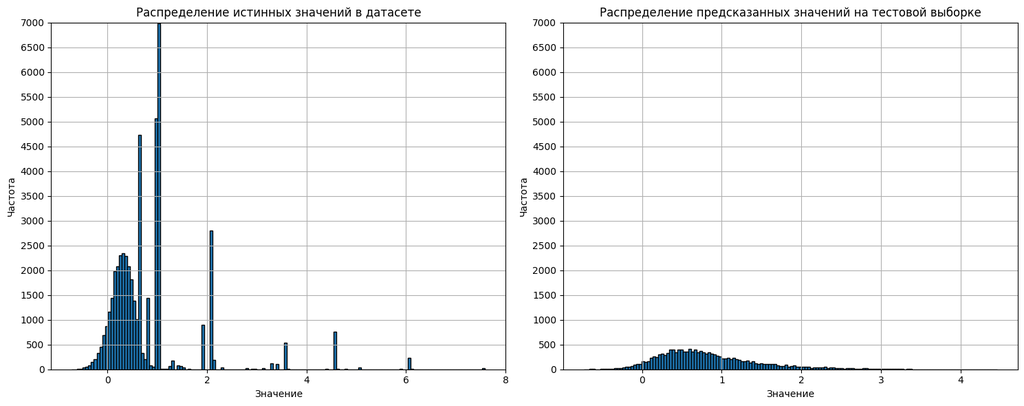

```python
fig, (ax1, ax2) = plt.subplots(1, 2, figsize=(15, 6))

ax1.hist(data['y'], bins=150, edgecolor='black')
ax1.set_title('Распределение истинных значений в датасете')
ax1.set_xlabel('Значение')
ax1.set_ylabel('Частота')
ax1.set_ylim(0, 7000)
ax1.set_yticks(np.arange(0, 7001, 500))
ax1.grid(True)

ax2.hist(y_pred, bins=150, edgecolor='black')
ax2.set_title('Распределение предсказанных значений на тестовой выборке')
ax2.set_xlabel('Значение')
ax2.set_ylabel('Частота')
ax2.set_ylim(0, 7000)
ax2.set_yticks(np.arange(0, 7001, 500))
ax2.grid(True)

plt.tight_layout()
plt.show()
```

```python
# Сколько предсказано примеров со степенью токсичности выше 4 в тестовой выборке?
print(len(error_analysis_df[error_analysis_df['Prediction'] > 4]))

# А сколько их на самом деле?
print(len(error_analysis_df[error_analysis_df['Target'] > 4]))
```

```
7
309
```

Можно заметить, что наибольшие ошибки модель допускает на примерах с истинно высокой степенью токсичности. Если посмотреть на гистограмму распределения истинных значений в датасете, видно, что существует большой дисбаланс между примерами - большинство из них имеют низкую степень токсичности. Скорее всего, модели не хватило данных для обучения токсичным комментариям, и она часто принимает их за нейтральные. Особенно, если текст примера содержит также много нейтральных слов.

Можем дополнительно посчитать число примеров, где предсказание превышает хотя бы 4 - таких всего несколько штук. На самом деле их в разы больще.